# The Fourier Transform and its Applications

Austin Joseph

The fourier transform is a type of data transformation that is used widely in audio and visual processing applications. The fourier transformation, at its core, is an extension of the fourier series, which is an a series of trigonometric functions. Similar to how a taylor series gives a polynomial approximation of a function, a fourier series is capable of giving an approximation of a periodic wave. With a series expansion it's possible to see how a complicated wave can be represented as a sum of sine and cosine waves, and from that we can visually represent this as a chart in which the x value is the frequency of the substituent waves, and the y value is the frequency. How is this useful? Many applications use this wave decomposition in order to analyze signals and gain inferences from them. A notable example is the use of FTs and iFTs (inverse fourier transforms) in MRI imaging. First, a fourier transform is taken of the raw MRI echo, which separates the raw signal into a sum of many different frequencies. This information is then stored in an array, dubbed k space. After the MRI scan is complete, an inverse fourier transform is taken of every pixel in kspace, and the result is summed in order to generate the final image. This is a 2d example of multiple waves adding together to create a complex wave. The fourier transform is not just limited to 2d applications and is often used in 1d applications, a classic case being audio processing and analysis.

One might have seen the classic audio visualizer (image taken from stack overflow, purely used as an example):

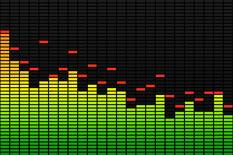

Clearly the horizontal axis represents the frequency of the sound while the y axis represents the relative amplitude of the corresponding frequency. This is particularly useful for isolating signals and sources of signals from a complicated response that a scanner or some detection apparatus might read. It's also fun to look at when listening to music! The remainder of this application discussion will look at the 1D example and various ways of representing the transform.

### The Fourier Transform

The fourier transform is given as $$ F(k)=\int_{-\infty}^{\infty}f(x)e^{-2i \pi kx}dx $$ Which can be discretized to $$ X_k = \sum_{k=0}^{N-1}x_n e^{-2i \pi kn/N} $$ This equation can make use of the Euler Formula to assist in evaluating it $$ e^{ix} = cos(x)+ i \ sin(x) $$

**How is this interpreted?** We'll use music recordings as an example of time series data. In a recording, the amplitude of a signal is taken tens of thousands of times per second. When graphed, the x values of the graph is the index of the amplitude, and the amplitude itself is the y value. When a slice of this wave is taken, the total number of points in the data is given as N, the amplitude of the signal is $x_n$ where n is the index of the amplitude. k here is used as the index of the resultant transform, and is also the iterator in the sum. Because of this, we can represent this sum as a product of matrices.

### Discrete Fourier Transform in Matrix Notation

$$ \begin{bmatrix} X_0\\ X_1\\ X_2\\ \vdots\\ X_k \end{bmatrix} = \begin{bmatrix} e^{-2i \pi (0)(0)/N} & e^{-2i \pi (0)(1)/N} & e^{-2i \pi (0)(2)/N} & \cdots & e^{-2i \pi (0)(n)/N}\\ e^{-2i \pi (1)(0)/N} & e^{-2i \pi (1)(1)/N} & e^{-2i \pi (1)(2)/N} & \cdots & e^{-2i \pi (1)(n)/N}\\ e^{-2i \pi (2)(0)/N} & e^{-2i \pi (2)(1)/N} & e^{-2i \pi (2)(2)/N} & \cdots & e^{-2i \pi (2)(n)/N}\\ \vdots & \vdots & \vdots & \ddots & \vdots \\ e^{-2i \pi (k)(0)/N} & e^{-2i \pi (k)(1)/N} & e^{-2i \pi (k)(2)/N} & \cdots & e^{-2i \pi (k)(n)/N} \end{bmatrix} \begin{bmatrix} x_0\\ x_1\\ x_2\\ \vdots\\ x_n \end{bmatrix} $$

### The Fast Fourier Transform

An important distinction to make is that this transformation matrix is a symmetric matrix, as from inspection, the matrix is square and k and n are the indexes of the transformation matrix. This has far reaching implications in the realm of computer science, as several algorithms have been developed that utilize the structure of this matrix to elect to not perform redundant calculations. Additionally, the number of calculations that need to be done can also be reduced by the fact that powers of $e^{-2i \pi/N}$ is periodic in nature. $e^{-2i \pi kn/N}=(e^{-2i \pi/N})^{kn}$. The fast fourier transform is an algorithm of discrete fourier transform that runs in $O(n) = Nlog(N)$ time instead of the $N^2$ time typical of matrix multiplication. This allows faster computing of the fourier transform and therefore enables real time analysis in some applications!

## Application Example: Audio Spectrum Analysis

In this example I will take a small sound clip (less than two hundreths of a second) from an iconic song and use an implementation of the DFT to isolate frequency components from the sound clip.

```python
from scipy.io import wavfile
import numpy as np
import matplotlib.pyplot as plt
```

```python
samplerate,data = wavfile.read("Rick Roll Sound Effect.wav")
```

```
Time of segment: 0.0045 seconds
```

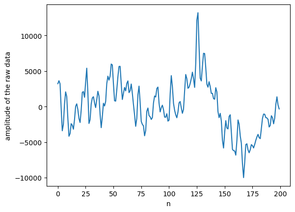

```python
# this code selects the  audio segment and displays it
t = 270000
x = data[t:t+200,0]
print(f"Time of segment: {len(x)/samplerate:.4f} seconds")

plt.ylabel("amplitude of the raw data")
plt.xlabel("n")
plt.plot(x)
plt.show()
```

```python
# this is our implementation of the discrete fourier transform, utilizing matrix multiplication
# this implementation is a 1 to 1 analogue of the formulas given above, and therefore isn't FFT
# as a result, it might not be suitable for realtime applications
def DFT(x):
    N = len(x)
    n = np.arange(N)
    k = n.reshape((N, 1))
    e = np.exp(-2j * np.pi * k * n / N)
    X = e @ x
    return X
```

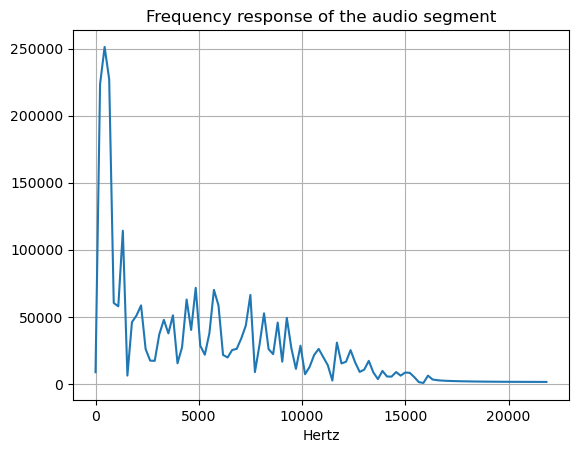

```python
from scipy.fft import fftfreq
N = len(x)
T = 1/samplerate
yf = DFT(x) # our DFT matrix math
xf = fftfreq(N, T)[:N//2] # this built in function used so proper frequency values can be obtained
plt.plot(xf, np.abs(yf[0:N//2])) # typically, only positive values are represented
plt.xlabel("Hertz")
plt.title("Frequency response of the audio segment")
plt.grid()
plt.show()
```

Notice how the Hertz values are within human listening frequency ranges! This is not a coincidence.

## References

[1] Gallagher, T. A., Nemeth, A. J., & Hacein-Bey, L. (2008). An introduction to the Fourier transform: Relationship to MRI. American Journal of Roentgenology, 190(5), 1396–1405. https://doi.org/10.2214/ajr.07.2874  
[2] Chapter 48. medical image reconstruction with the FFT. NVIDIA Developer. (n.d.). https://developer.nvidia.com/gpugems/gpugems2/part-vi-simulation-and-numerical-algorithms/chapter-48-medical-image-reconstruction  
[3] https://stackoverflow.com/questions/12844588/create-audio-spectrum-visualizer-android-app  
[4] Weisstein, Eric W. "Fourier Transform." From MathWorld--A Wolfram Web Resource. https://mathworld.wolfram.com/FourierTransform.html  
[5] Weisstein, Eric W. "Discrete Fourier Transform." From MathWorld--A Wolfram Web Resource. https://mathworld.wolfram.com/DiscreteFourierTransform.html  
[6] https://web.mit.edu/~gari/teaching/6.555/lectures/ch_DFT.pdf  
[7] https://ocw.mit.edu/courses/6-003-signals-and-systems-fall-2011/resources/mit6_003f11_lec16/  
[8] https://www.cs.cmu.edu/afs/andrew/scs/cs/15-463/2001/pub/www/notes/fourier/fourier.pdf